# End to End Analysis of an Internship Dataset: A Comprehensive Report

## **Exploratory Data Analysis of the Internship Dataset**

This document contais the exploratory data analysis performed on a dataset containing Internship data. The original dataset was sourced from kaggle, the cleaning and preprocessing of the dataset was performed through Microsoft Excel and SQL via Google's BigQuery.

Disclaimer: The metrics and analytics presented in this report are derived from a pre-sourced dataset obtained from Kaggle and are part of an independent analytics project. The creator of this report does not claim any responsibility for the accuracy, completeness, or real-life applicability of the findings. The information provided is based on the dataset available and may not reflect current or real-world conditions.

As seen below the dataset contains 8 columns and 6452 unique rows

```
<class 'pandas.core.frame.DataFrame'>
RangeIndex: 6452 entries, 0 to 6451
Data columns (total 8 columns):
 #   Column                  Non-Null Count  Dtype
---  ------                  --------------  -----
 0   Role                    6452 non-null   object
 1   Organization            6452 non-null   object
 2   Location                6452 non-null   object
 3   Start Date              6452 non-null   object
 4   Duration in Months      6452 non-null   float64
 5   Average Monthy Stipend  6452 non-null   float64
 6   Added Incentives        6452 non-null   object
 7   Currency                6452 non-null   object
dtypes: float64(2), object(6)
memory usage: 403.4+ KB
```

|  | Role | Organization | Location | Start Date | Duration in Months | Average Monthy Stipend | Added Incentives | Currency |
| --- | --- | --- | --- | --- | --- | --- | --- | --- |
| 0 | Talent Acquisition | Marpu Foundation | Remote | Immediately | 0.25 | 0.0 | No | INR |
| 1 | Social Work | Marpu Foundation | Remote | Immediately | 0.25 | 0.0 | No | INR |
| 2 | Event Coordination | Aam Aadmi Party | Delhi | Immediately | 0.25 | 0.0 | No | INR |
| 3 | Human Resources (HR) | Subhansh Sewa Trust | Remote | Immediately | 0.25 | 0.0 | No | INR |
| 4 | Induction Representation | Subhansh Sewa Trust | Remote | Immediately | 0.25 | 0.0 | No | INR |

The following is the structure of a dataset derived, from the original dataset, from sql. This shows us the nuber of internship vacancies for various ranges of stipends

```
<class 'pandas.core.frame.DataFrame'>
RangeIndex: 38 entries, 0 to 37
Data columns (total 2 columns):
 #   Column              Non-Null Count  Dtype
---  ------              --------------  -----
 0   stipend_range       38 non-null     object
 1   number_of_openings  38 non-null     int64
dtypes: int64(1), object(1)
memory usage: 736.0+ bytes
```

|  | stipend_range | number_of_openings |
| --- | --- | --- |
| 0 | 0 or less | 218 |
| 1 | 0-999 | 35 |
| 2 | 10000-10999 | 873 |
| 3 | 1000-1999 | 481 |
| 4 | 11000-11999 | 145 |

The plot below depicts a bar graph of the top 20 pay ranges against the number of openings. As inferred from the graph, the most commonly offered pay lies between the range of INR 5000 to INR 5999 with over 800 internships offering the same.

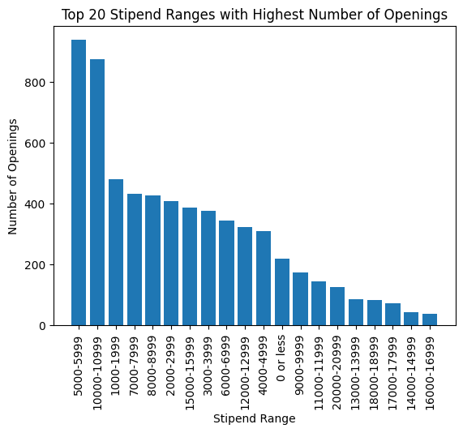

The Scatter plot below shows the relationship between the Average Monthly Stipend and the Average Duration of the internship, from the graph it is observed that a longer tenure of internship does not really indicate a higher pay

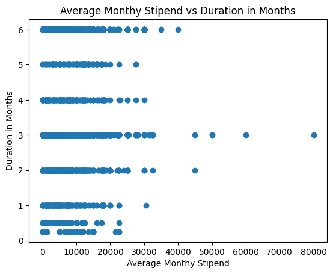

The below Pie Chart shows the ratio of the number of remote internships to in person internships. We can observe that the ratio between the number of in-person internsips to the remote internships is around 1.27:1.

```
Number of Remote Roles: 2843
Number of Inperson Roles: 3609
```

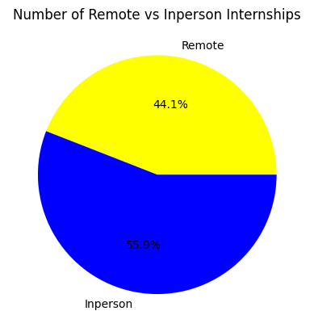

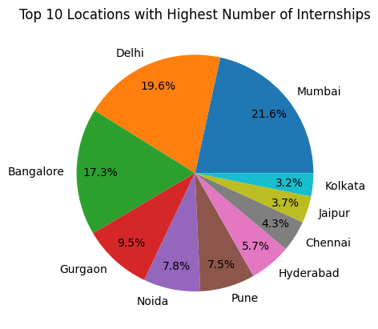

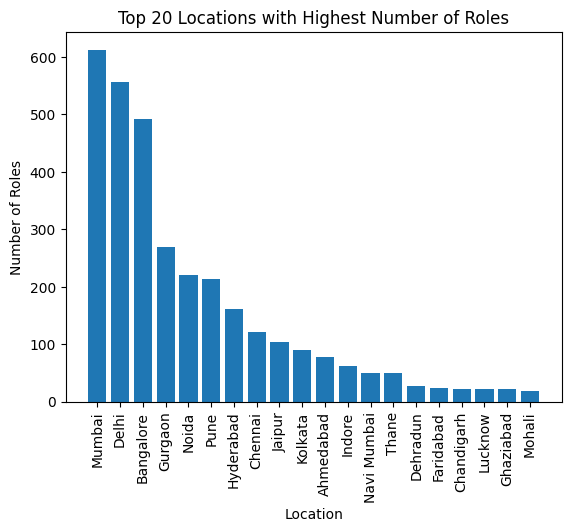

The following list and bar graph depict 50 of the most offered internship positions, as we can see that the Business Develeopment in the department of Sales tops the list with 371 openings across India.

```
Role
Business Development (Sales)          371
Social Media Marketing                361
Digital Marketing                     361
Graphic Design                        327
Human Resources (HR)                  305
Content Writing                       215
Marketing                             137
Video Making/Editing                   92
Search Engine Optimization (SEO)       80
Sales                                  76
Business Development                   68
Operations                             64
Telecalling                            50
Web Development                        50
Law/Legal                              50
Video Editing                          49
Recruitment                            36
WordPress Development                  36
UI/UX Design                           35
Market Research                        33
Talent Acquisition                     31
Architecture                           30
Campus Ambassador                      30
Social Media Management                30
Data Entry                             29
Field Sales                            26
Flutter Development                    26
Interior Design                        26
Full Stack Development                 26
Event Management                       25
Fashion Design                         25
Finance                                23
Sales And Marketing                    23
Photography                            22
Influencer Marketing                   21
Product Management                     20
Android App Development                20
Customer Service                       20
Lead Generation                        20
Content Creation                       18
HR                                     18
Corporate Sales                        18
Fundraising                            17
Copywriting                            17
Mobile App Development                 17
Front End Development                  15
International Business Development     15
Motion Graphics                        15
UX/UI Design                           14
Project Management                     13
Name: Role, dtype: int64
```

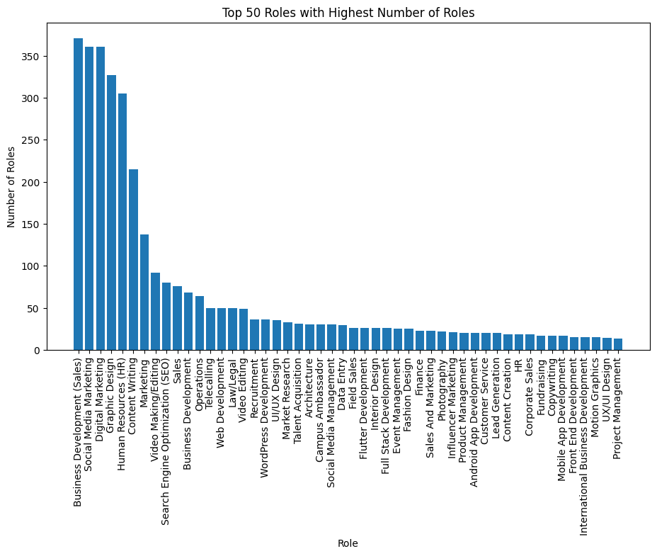

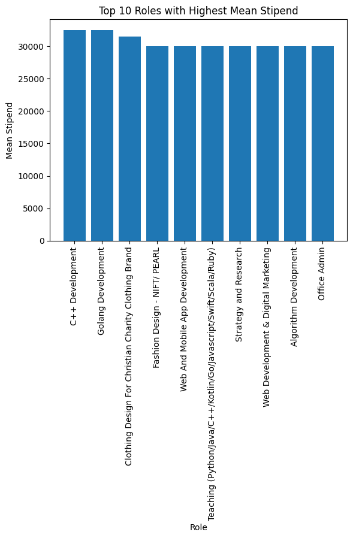

Below is the list of 10 companies that offer the highest average stipends to the candidates.

```
Organization
Desigo Milk                                     80000.0
Saathi Eco Innovations India Private Limited    60000.0
Ekostay LLP                                     50000.0
The Concept Co.                                 50000.0
GoComet                                         45000.0
Digit88                                         40000.0
NOIR & BLANCO                                   35000.0
Nerdy Academy                                   32500.0
AltaSierra                                      31500.0
Runpluson Private Limited                       30500.0
Name: Average Monthy Stipend, dtype: float64
```

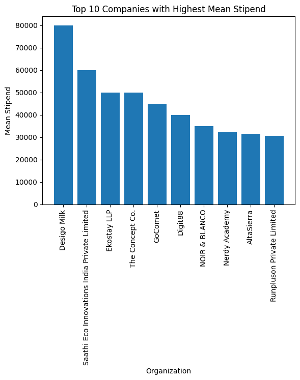

The following Graph depicts 15 companies that have the most amount of internship offerings

```
Organization
Top Talent Bridge                                 49
Stirring Minds                                    31
HappiMynd                                         30
Pawzz                                             26
Narigiri's Connect To Universe Private Limited    26
Pereyan LLP                                       22
Blackcoffer                                       22
Avaari                                            19
Across The Globe (ATG)                            19
Buddha Education Association Incorporation        18
QA Solvers                                        18
Eduminatti                                        18
Shubh International                               17
Qriocity Ventures Private Limited                 17
HaZZten                                           17
Name: Role, dtype: int64
```

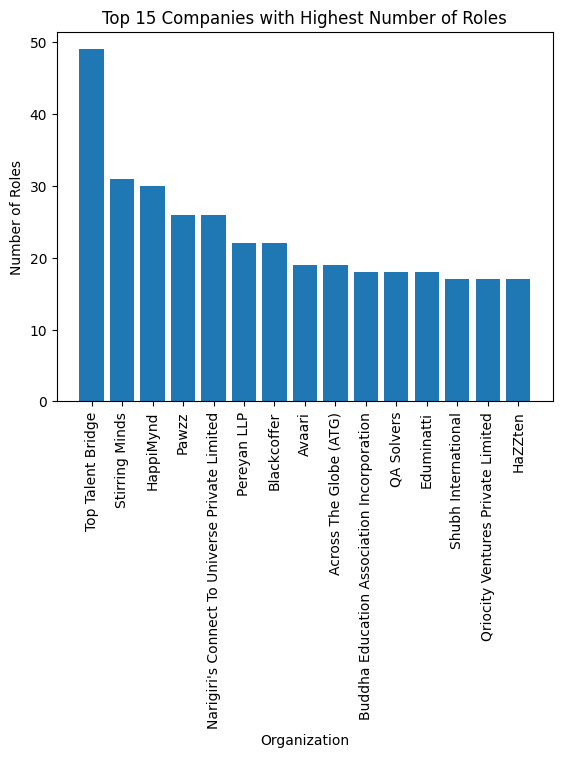

# **Descriptive and Geospatial Analytics on the Stipend Dataset**

This document is a continuation to the exploratory data analysis on the stipend dataset, here we aim to draw out insights and create supplementary datastes to answer our objective questions and aid in creating an interactive dashboard of the findings as well as a prediction model

**Disclaimer:** The metrics and analytics presented in this report are derived from a pre-sourced dataset obtained from Kaggle and are part of an independent analytics project. The creator of this report does not claim any responsibility for the accuracy, completeness, or real-life applicability of the findings. The information provided is based on the dataset available and may not reflect current or real-world conditions.

```
<class 'pandas.core.frame.DataFrame'>
RangeIndex: 6452 entries, 0 to 6451
Data columns (total 8 columns):
 #   Column                   Non-Null Count  Dtype
---  ------                   --------------  -----
 0   Role                     6452 non-null   object
 1   Organization             6452 non-null   object
 2   Location                 6452 non-null   object
 3   Start Date               6452 non-null   object
 4   Duration in Months       6452 non-null   float64
 5   Average Monthly Stipend  6452 non-null   float64
 6   Added Incentives         6452 non-null   object
 7   Currency                 6452 non-null   object
dtypes: float64(2), object(6)
memory usage: 403.4+ KB
```

|  | Role | Organization | Location | Start Date | Duration in Months | Average Monthly Stipend | Added Incentives | Currency |
| --- | --- | --- | --- | --- | --- | --- | --- | --- |
| 0 | Talent Acquisition | Marpu Foundation | Remote | Immediately | 0.25 | 0.0 | No | INR |
| 1 | Social Work | Marpu Foundation | Remote | Immediately | 0.25 | 0.0 | No | INR |
| 2 | Event Coordination | Aam Aadmi Party | Delhi | Immediately | 0.25 | 0.0 | No | INR |
| 3 | Human Resources (HR) | Subhansh Sewa Trust | Remote | Immediately | 0.25 | 0.0 | No | INR |
| 4 | Induction Representation | Subhansh Sewa Trust | Remote | Immediately | 0.25 | 0.0 | No | INR |

## **Objective Quetions**

1. How many companies are offering internships?
2. How many locations across India have internship openings?
3. What is the ratio of remote to inperson internships?
4. Which locations host the highest number of internships and which location offers the highest stipends on average?
5. Which companies have the highest number of openings and which comapnies offer the highest stipends?
6. Which roles pay the most on average?

## First Let us observe preliminary details in the dataset

```
Total number of offering Companies:  4656
Total Number of open positions:  6452
Total number of Locations across India:  172
Total number of Remote Roles:  2843
Total number of In-Person Roles:  3609
```

From the initial observations we see that

1. There are 6452 internship openings
2. There are 4656 companies offering internhips
3. The internships are spread across 172 locations in India
4. There are 2843 remote internships and 3609 in-person internships

Next we head into analyzing the data to draw out inshights

## **1. Descriptive Analytics**

**1 A. Location Analysis** The next cells contain the Detailed Analysis of each loaction where internships are open

```
Locations offering Highest Mean Stipend:
 Location
Warangal        30000.00
Indiranagara    30000.00
Jodhpur         29000.00
North Goa       25000.00
Tamil Nadu      20000.00
                  ...
Karur            2000.00
Villupuram       2000.00
Pudukkottai      2000.00
Kanchipuram      2000.00
Haryana          1666.67
Name: Average Monthly Stipend, Length: 173, dtype: float64


 Locations offering Highest Median Stipend:
 Location
Indiranagara    30000.00
Warangal        30000.00
North Goa       25000.00
Tamil Nadu      20000.00
Varanasi        18500.00
                  ...
Bhavnagar        2000.00
Agartala         2000.00
Pudukkottai      2000.00
Kanchipuram      2000.00
Haryana          1666.67
Name: Average Monthly Stipend, Length: 173, dtype: float64
```

As we can see Warangal offers the highest average stipend

Now we see the pay disparity between remote and in-person internships

```
Mean Remote Stipend:  6000.390608512135
Mean In-Person Stipend:  9237.665929620394
```

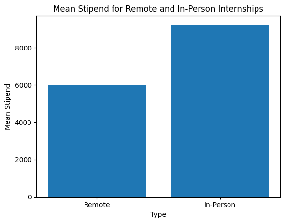

Thus we see that the average stipend for onsite internships is more when compared to that of remote internships

```
Location
Remote       2843
Mumbai        613
Delhi         556
Bangalore     493
Gurgaon       269
Noida         221
Pune          213
Hyderabad     162
Chennai       121
Jaipur        104
Name: Role, dtype: int64


Stipends in the top 10 locations:

Location
Bangalore    10000.0
Chennai      10000.0
Delhi         8500.0
Gurgaon      10000.0
Hyderabad    10000.0
Jaipur        8000.0
Mumbai        9000.0
Noida         9000.0
Pune          8000.0
Remote        5000.0
Name: Average Monthly Stipend, dtype: float64
```

**1 B. Sector Analytics**

Now we analyze and find 20 companies with the highest number of openings

```
Organization
Top Talent Bridge                                 49
Stirring Minds                                    31
HappiMynd                                         30
Pawzz                                             26
Narigiri's Connect To Universe Private Limited    26
Pereyan LLP                                       22
Blackcoffer                                       22
Avaari                                            19
Across The Globe (ATG)                            19
Buddha Education Association Incorporation        18
QA Solvers                                        18
Eduminatti                                        18
Shubh International                               17
Qriocity Ventures Private Limited                 17
HaZZten                                           17
Energy Alternatives India                         16
Lawtech                                           15
Trading Shalaa                                    15
Nettv4u                                           15
Graveiens Eduservices Private Limited             15
Name: Role, dtype: int64
```

Next we see the comapnies which offer the 20 highest median stipends across india

```
Organization
Desigo Milk                                     80000.0
Saathi Eco Innovations India Private Limited    60000.0
The Concept Co.                                 50000.0
Ekostay LLP                                     50000.0
GoComet                                         45000.0
Digit88                                         40000.0
NOIR & BLANCO                                   35000.0
WiJungle - by HttpCart                          32500.0
Nerdy Academy                                   32500.0
AltaSierra                                      31500.0
Runpluson Private Limited                       30500.0
Health Hub India                                30000.0
Bodii                                           30000.0
DigiKind Co. (DKC)                              30000.0
Salesken                                        30000.0
Failure Before Success                          30000.0
PickYourTrail                                   30000.0
Technest Learning                               30000.0
Kaspr International                             30000.0
Furnishka.com                                   30000.0
Name: Average Monthly Stipend, dtype: float64
```

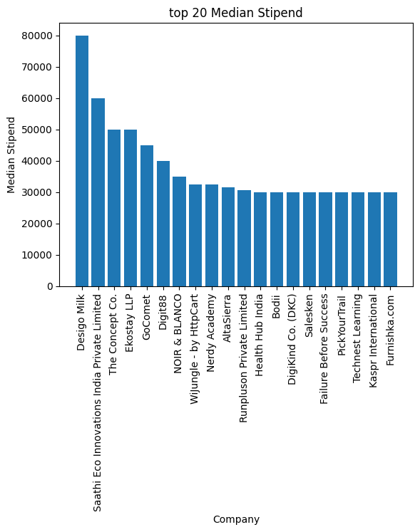

Now we Analyze various industries and internship positions in order to find which pay the post

```
Role
C++ Development                                                     32500.0
Golang Development                                                  32500.0
Clothing Design For Christian Charity Clothing Brand                31500.0
Teaching (Python/Java/C++/Kotlin/Go/Javascript/Swift/Scala/Ruby)    30000.0
Product Support Engineering                                         30000.0
                                                                     ...
Human Resources (teams)                                                 0.0
Convolution Neural Network                                              0.0
Social Work                                                             0.0
Archaeology Event Management                                            0.0
Business Analyst (Marketing)                                            0.0
Name: Average Monthly Stipend, Length: 2162, dtype: float64
```

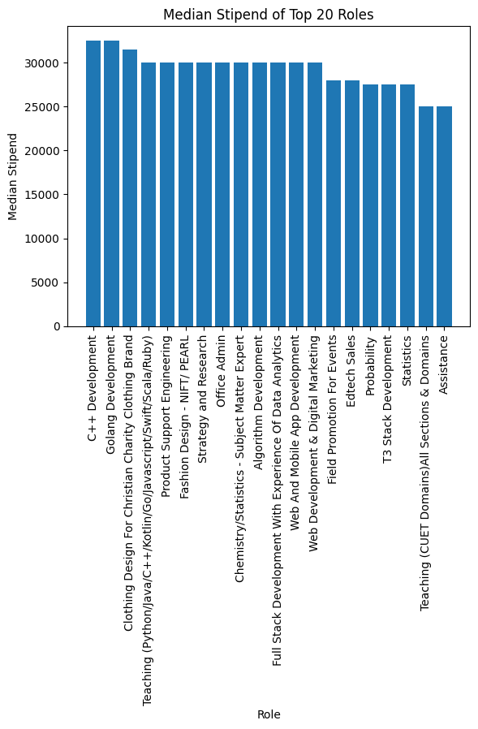

As clearly shown from the graph and table above internships in fields such as C++ and Golang development pay more than most other fields, followed by positions such as product support engineering and fashion designing

**1 C. Incentive and Duration Analysis**

Now we will analyze the dataset by duration of internships and added incentives

```
Number of internships which offer additional incentives:  171
Number of companies offering incentives:  135
Mean Stipend with incentives: 2073.099
Mean Stipend without incentives: 8201.436
```

```
Mean Duration with incentives: 3.89 months
Mean Duration without incentives: 3.83 months
```

## **2. GeoSpatial Analytics**

Now we go into the Geospatial analysis of the dataset, we shall focus on identifying and visualizing locations of the in-person internships on a political map,to get an idea of how these openings are spread across the country.

To plot the map we first have to obtain the lattitudes and longitude of each location, this is achieved by using geopy.encoders and the map is plotted using plotly express

[interactive chart not shown]

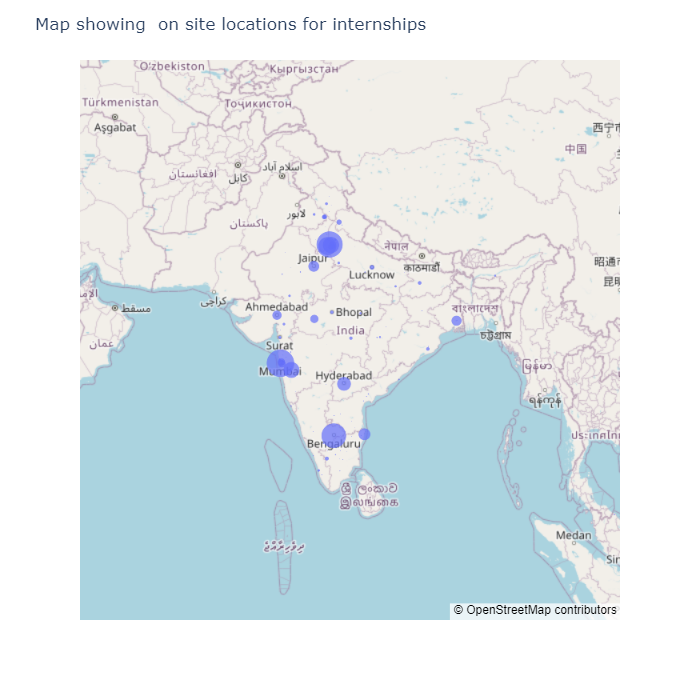

The above map shows the spread of internships across India and the size of the bubbles is determined by the number of openings

# **Dashboard of the key findings**

Below is the Tableau dashboard built out of the key findings

[figure not shown]

# **Conclusions drawn from analysis**

1. How many companies are offering internships? A. There are 4656 companies offering internhips
2. How many locations across India have internship openings? The internships are spread across 172 locations in India.
3. What is the ratio of remote to inperson internships? There are 2843 remote internships and 3609 in-person internships, which is ratio of approximately 1.26:1
4. Which locations host the highest number of internships and which location offers the highest stipends on average? We see that Delhi,Mumbai and Bangalore are the 3 most poular cities in India for internships and Warangal is seen to have the highest average stipend compared to other locations.
5. Which companies have the highest number of openings and which comapnies offer the highest stipends? To answer this question we have obtained a list of 20 companies showing which ones have the most number of vacanies and which offer the highest median stipend.
6. Which roles pay the most on average? It is seen that C++ and golang development development pay the highest stipends on average, followed by fields such as product engineering and fashion design, we have drawn out graphs and lists to support the findings.

These are 6 major findings from the exploratory data analysis and the Descriptive,Sector and Geospatial Analysis if the dataset.